# Assignment 5

Zulikah Latief (s4273281)

1/12/2022

```
## Loaded package itsadug 2.4 (see 'help("itsadug")' ).
```

```r
#load data
load("data_DykesRivers.rda")
head(dat)
```

```
##        Subject Condition Block Trial  Dur       RT prev.Dur
## 1 s81112112644        DR     1     1 2000 1856.376       NA
## 2 s81112112644        DR     1     3 2000 2298.246     3100
## 3 s81112112644        DR     1     5 2000 1708.988     3100
## 4 s81112112644        DR     1     7 2000 2057.195     3100
## 5 s81112112644        DR     1     9 2000 2164.245     3100
## 6 s81112112644        DR     1    11 2000 2391.830     3100
```

```r
table(dat$Subject, dat$Condition)
```

```
##
##                 DR  FF  RD
##   s81112112644 183   0   0
##   s81113105409   0   0 183
##   s81113113938 183   0   0
##   s81114092619   0   0 183
##   s81114100422   0   0 183
##   s81114113726 183   0   0
##   s81114121240 183   0   0
##   s81117091626   0   0 183
##   s81117092623 183   0   0
##   s81117100546   0   0 183
##   s81117104859 183   0   0
##   s81117113740   0   0 183
##   s81118091748 183   0   0
##   s81118091908   0   0 183
##   s81118095224 183   0   0
##   s81118095527   0   0 183
##   s81118104741 183   0   0
##   s81118105112   0   0 183
##   s81118112603 183   0   0
##   s81118113041   0   0 183
##   s81119104623   0   0 183
##   s81119104836 183   0   0
##   s81119113321   0   0 183
##   s81120091328   0 183   0
##   s81120100631   0 160   0
##   s81120113329   0 183   0
##   s81121092225   0 183   0
##   s81121100801   0 183   0
##   s81121104752   0 183   0
##   s81121112553   0 183   0
##   s81121112934   0 183   0
##   s81124091911   0 183   0
##   s81124095652 183   0   0
##   s81124104137   0 183   0
##   s81124105007   0   0 183
##   s81125092308   0 183   0
##   s81125095536 183   0   0
##   s81125100241   0 183   0
##   s81125104725 183   0   0
##   s81125110819   0 183   0
##   s81125113835 183   0   0
##   s81125114302   0 183   0
##   s81126103931   0   0 183
##   s81126104329 183   0   0
##   s81202105231   0 183   0
##   s81202113621   0   0 183
##   s81202130059   0 183   0
##   s81202152418   0   0 183
```

```r
unique(dat$Subject)
```

```
##  [1] "s81112112644" "s81113105409" "s81113113938" "s81114092619" "s81114100422"
##  [6] "s81114113726" "s81114121240" "s81117091626" "s81117092623" "s81117100546"
## [11] "s81117104859" "s81117113740" "s81118091748" "s81118091908" "s81118095224"
## [16] "s81118095527" "s81118104741" "s81118105112" "s81118112603" "s81118113041"
## [21] "s81119104623" "s81119104836" "s81119113321" "s81120091328" "s81120100631"
## [26] "s81120113329" "s81121092225" "s81121100801" "s81121104752" "s81121112553"
## [31] "s81121112934" "s81124091911" "s81124095652" "s81124104137" "s81124105007"
## [36] "s81125092308" "s81125095536" "s81125100241" "s81125104725" "s81125110819"
## [41] "s81125113835" "s81125114302" "s81126103931" "s81126104329" "s81202105231"
## [46] "s81202113621" "s81202130059" "s81202152418"
```

```r
tail(dat)
```

```
##           Subject Condition Block Trial  Dur       RT prev.Dur
## 8756 s81202152418        RD     9   355 2000 1976.774     3100
## 8757 s81202152418        RD     9   357 2000 1494.929     3100
## 8758 s81202152418        RD     9   359 2000 2016.976     3100
## 8759 s81202152418        RD     9   361 2000 2070.450     3100
## 8760 s81202152418        RD     9   363 2000 1950.052     3100
## 8761 s81202152418        RD     9   365 2000 2057.106     3100
```

This is a between subject study. Each subject only takes part in 1 of the three conditions.

## Analysis

### Question 1: Data

**Inspect the reaction times (column RT). Include the code and your answers to the following questions:**

**Describe the range of the reaction times, and check for outliers. (If you would find outliers, describe why and how you removed these and also calculate how many observations you removed.)**

The reaction times range between 169.5251ms and 5775.1789ms. Outliers can be seen in the boxplot below. There are no obvious outliers in the RT (i.e., no negative or zero RT) and thus no data is removed.

```r
#Median RT
median(dat$RT)
```

```
## [1] 2070.597
```

```r
#Mean RT
mean(dat$RT)
```

```
## [1] 2114.985
```

```r
#Range RT
range(dat$RT)
```

```
## [1]  169.5251 5775.1789
```

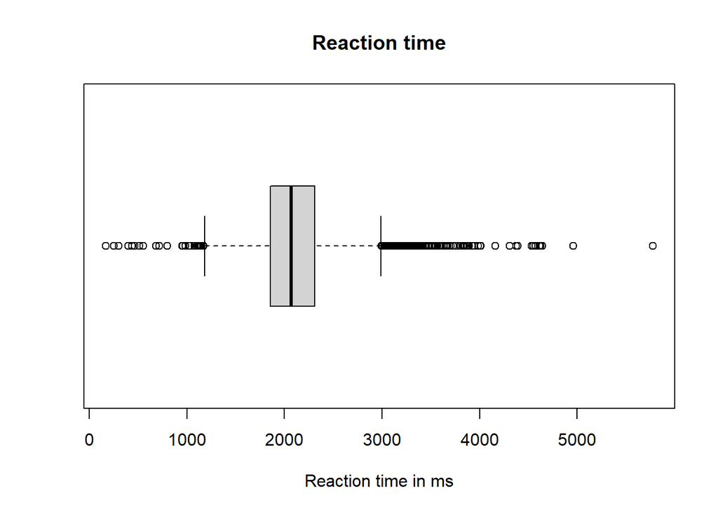

```r
#boxplot for RT
boxplot(dat$RT, main="Reaction time",
   xlab="Reaction time in ms", horizontal = TRUE)
```

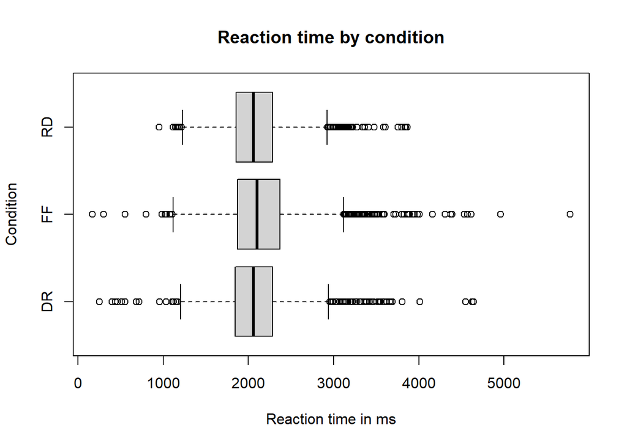

```r
#Boxplot of RT by Condition
boxplot(RT~Condition,data=dat, main="Reaction time by condition",
   xlab="Reaction time in ms", ylab="Condition", horizontal = TRUE)
```

**Visualize and describe the distribution of the reaction times.**

The qqnorm plot shows that the reaction times do not follow a strict normal distribution. It is skewed on both the tail ends. The data points that spread between 150ms to ~900ms have lower values and the observation above ~2300ms have higher values. It can also be observed that the distribution is more skewed on the right tail end and has a higher peak which resembles a T distribution.

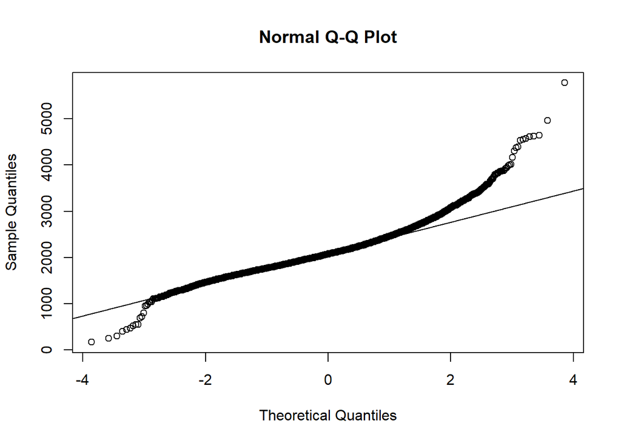

```r
#qqplot to visualise distribution of RTs
qqnorm(dat$RT)
qqline(dat$RT)
```

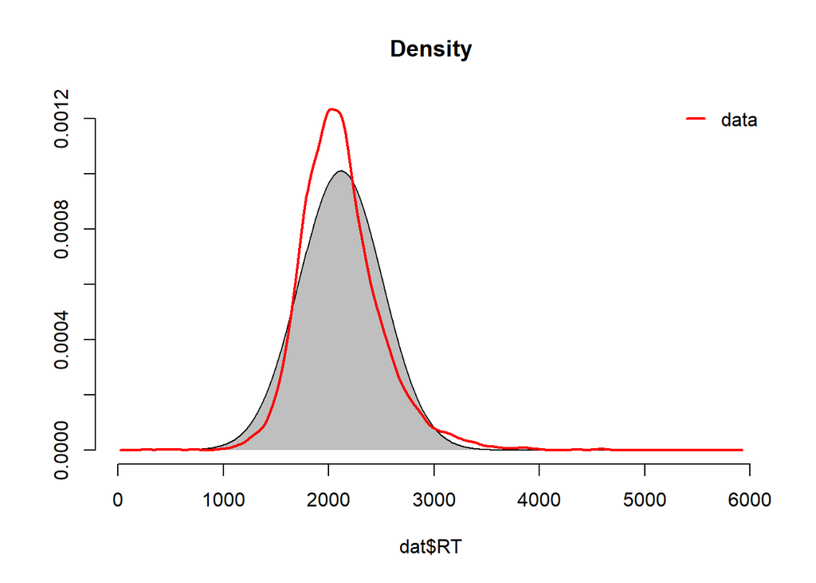

```r
#check distribution of reaction times with respect to normal distribution
check_normaldist(dat$RT, xlab = 'reaction time (ms)')
```

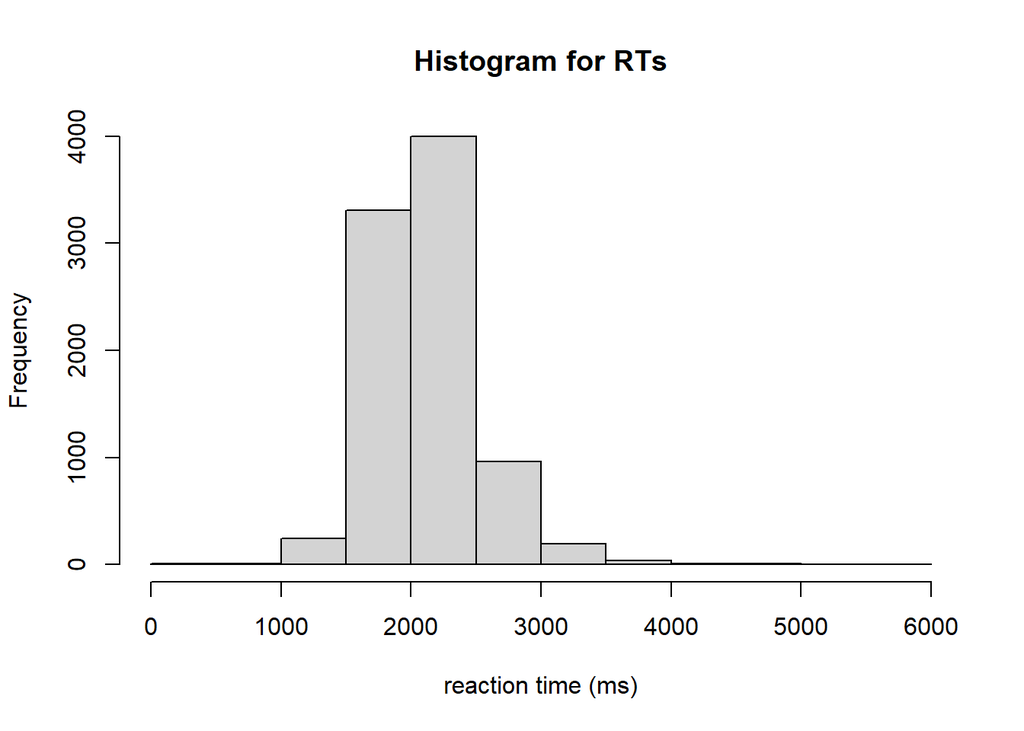

```r
#historgram of RTs
hist(dat$RT, xlab = 'reaction time (ms)', main = 'Histogram for RTs')
```

**List the predictors that you would like to include as random effects. Explain why this predictor/these predictors/combinations of predictors should be included as random effects rather than fixed effects.**

Condition can be taken as a fixed effect since it is an experimental manipulation. Prev duration can also be a fixed effect since we want to know if this long interval duration (i.e., prev duration) effects the estimation of the short interval.

Subjects can be taken as random effects since each subject might differ in their reaction times and we would want to generalize over new subjects. Trails and blocks can also be considered as random effects because in RT tasks the performance over the trails may change due to fatigueness. Since we want to check whether a change in the duration of the long intervals affects the short intervals it might be relevant to check whether over trails (or block) this affect varies.

## Question 2: Setup baseline model

**Setup a GAM model (i.e., without random effects) that includes the nonlinear interaction between Condition and Trial (which marks the trial sequence). Run the model and include the code in your report.**

```r
m1 <- bam( RT ~  Condition + s(Trial, by = Condition), data=dat)
summary(m1)
```

```
##
## Family: gaussian
## Link function: identity
##
## Formula:
## RT ~ Condition + s(Trial, by = Condition)
##
## Parametric coefficients:
##             Estimate Std. Error t value Pr(>|t|)
## (Intercept) 2085.638      7.222 288.770  < 2e-16 ***
## ConditionFF   75.878     10.234   7.414 1.34e-13 ***
## ConditionRD   12.596     10.214   1.233    0.218
## ---
## Signif. codes:  0 '***' 0.001 '**' 0.01 '*' 0.05 '.' 0.1 ' ' 1
##
## Approximate significance of smooth terms:
##                        edf Ref.df     F p-value
## s(Trial):ConditionDR 4.919  6.004 8.124  <2e-16 ***
## s(Trial):ConditionFF 1.001  1.001 5.411    0.02 *
## s(Trial):ConditionRD 6.740  7.855 9.014  <2e-16 ***
## ---
## Signif. codes:  0 '***' 0.001 '**' 0.01 '*' 0.05 '.' 0.1 ' ' 1
##
## R-sq.(adj) =  0.0207   Deviance explained = 2.24%
## fREML =  64712  Scale est. = 1.5273e+05  n = 8761
```

**Inspect the model fit by running the standard residual plots (the code is provided below). Use these plots to evaluate how the model meets the regression assumptions. What is your conclusion?**

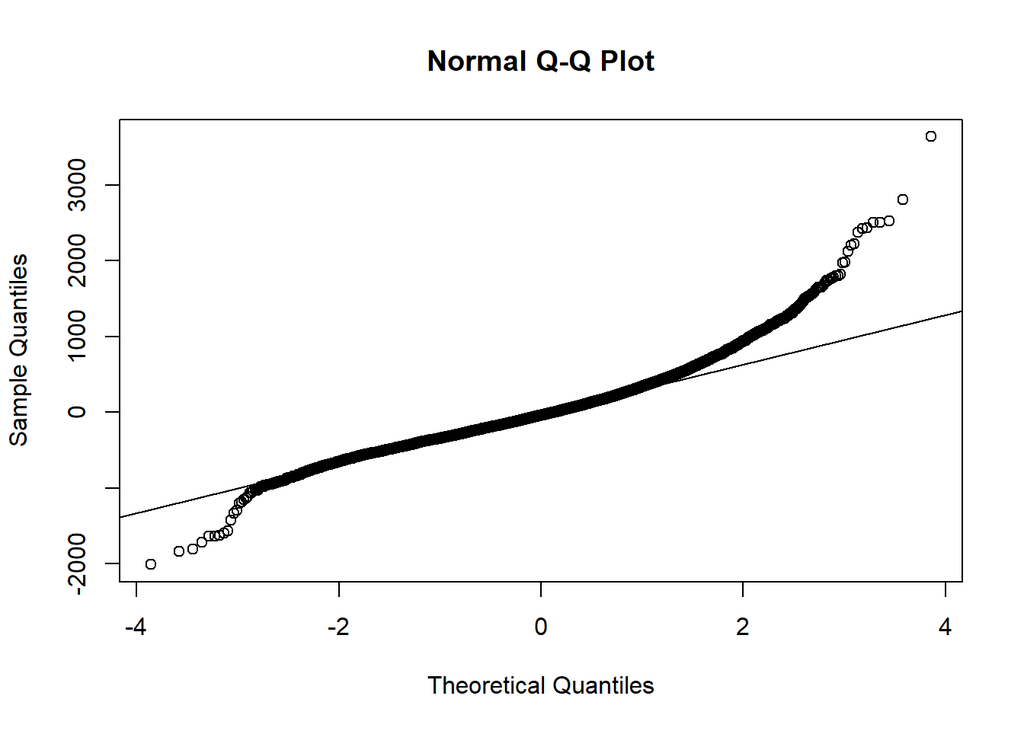

```r
# PLOT 1
qqnorm(resid(m1))
qqline(resid(m1))
```

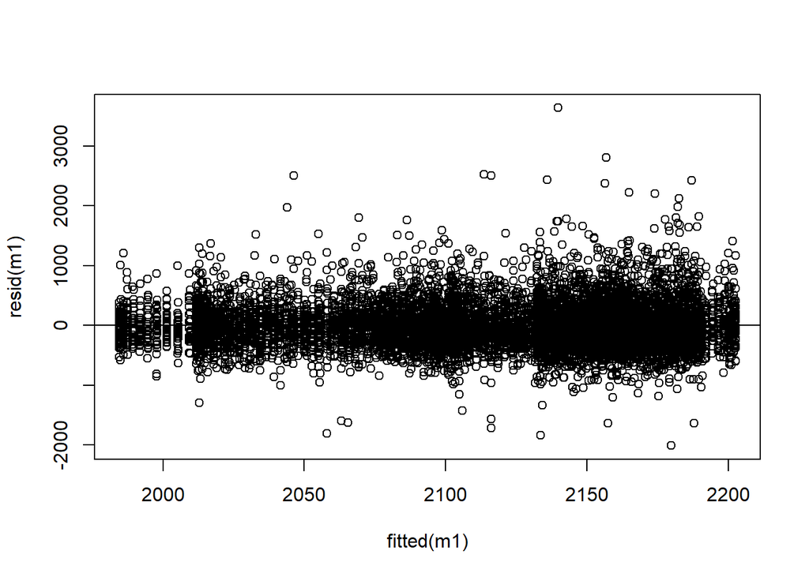

```r
# PLOT 2:
plot(fitted(m1), resid(m1))
abline(h=0)
```

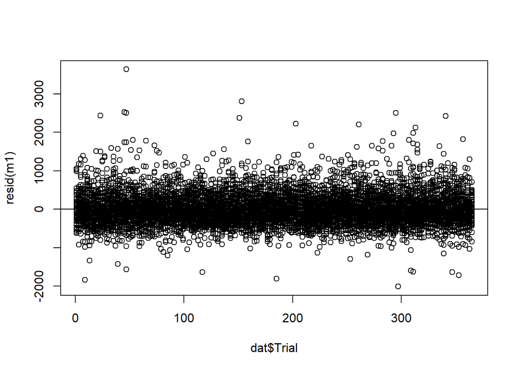

```r
plot(dat$Trial, resid(m1))
abline(h=0)
```

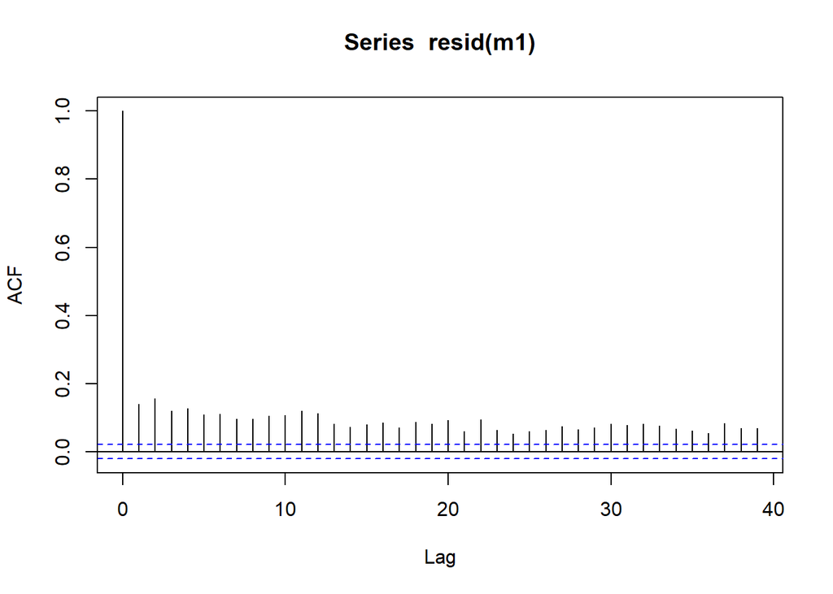

```r
# PLOT 3:
acf(resid(m1))
```

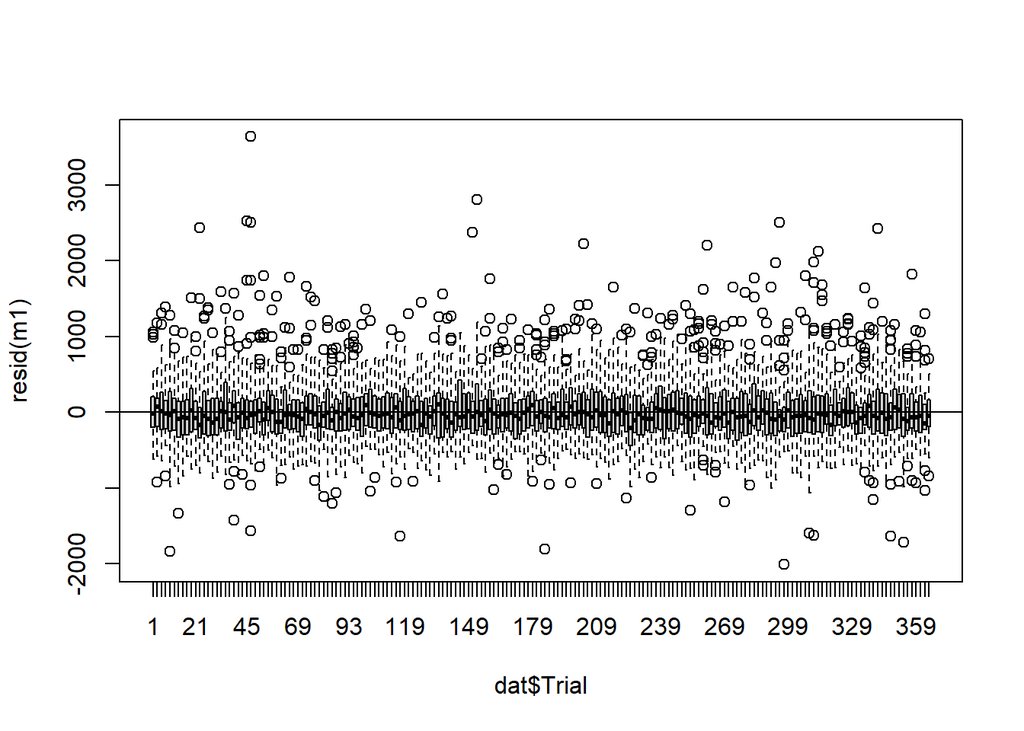

```r
#boxplot
boxplot(resid(m1) ~ dat$Trial)
abline(h=0)
```

```
## Summary:
##  * Condition : factor; set to the value(s): DR, FF, RD.
##  * Trial : numeric predictor; with 30 values ranging from 1.000000 to 365.000000.
##  * NOTE : No random effects in the model to cancel.
##
```

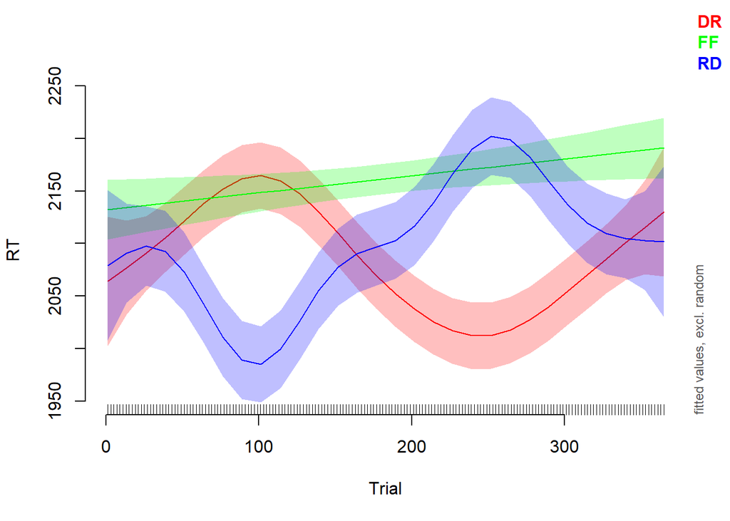

```r
#smooth plot showing the RTs by condition
plot_smooth(m1, view="Trial", plot_all="Condition")
```

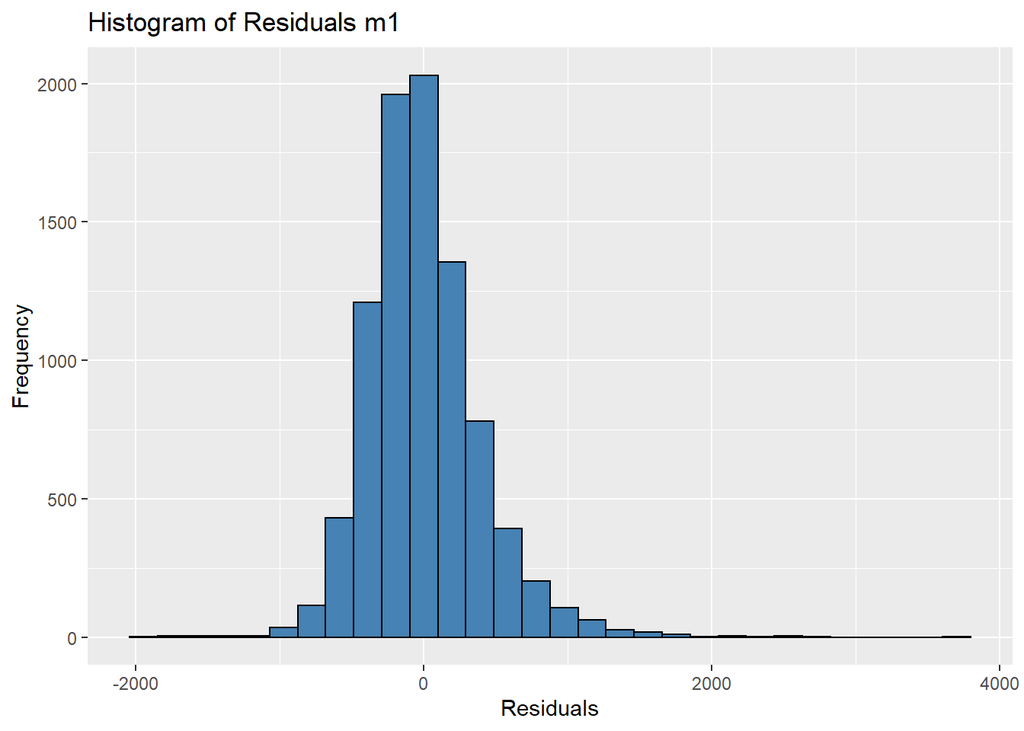

```r
#create histogram of residuals m1
ggplot(data = dat, aes(x = m1$residuals)) +
    geom_histogram(fill = 'steelblue', color = 'black') +
    labs(title = 'Histogram of Residuals m1', x = 'Residuals', y = 'Frequency')
```

qqnorm plot shows that the residuals do not follow a normal distribution (like the data). The residuals on the left end of the distribution are lower and the values on the right tail are higher. Overall, the distribution of residuals is skewed on both the tail ends (like the data).

resid vs fitted values shows a pattern of highly concentrated residuals followed by less concentrated residuals. For instance, the residuals below 2000ms start highly concentrated and gradually reduce in magnitude and density until around 2010ms. Post this, there is again a high concentration of residuals for a few ms, after which the concentration and magnitude reduces. This pattern occurs again at around 2100ms and between ~2140ms and ~2190ms. However, between ~2140ms and ~2190ms, the concentration and magnitude is relatively much higher. Overall, the magnitude of the residuals seem to increase with higher RTs. There is a clear pattern in the residuals.

resid vs trial shows an almost similar trend of residuals over the trials. There are slightly more higher magnitude residual values until the first 100 trials and towards the last 250-350 trials. The residuals mostly have higher RTs values than lower.

ACF lag 1 has a value close to 0.2 which suggests that there is a correlation between successive RTs. Furthermore, over the lags apattern of high-low ACF values can be seen.

Finally, the smooth plot shows the effect of the non-linear interaction between Trails and Condition on the RTs. For all three conditions, the error bars are wider in the beginning and end trials. Moreover, the box plot shows that over some cluster of trials the residuals are more concentrated.

## Question 3: Improve model fit

**Include random effect(s). Answer the following questions: Explain why you prefer the random effect(s) your selected to include. Run the model and include the code and summary in your report.**

To allow for the effect of the experiment to be generalized to people outside the study ‘Subject’ is modeled as a factor smooth over ‘Trial’ (to account for any non-linearity over the trials). A non-linear interaction between trial and condition is considered to evaluate if the RTs may differ over the trials for different conditions. This is relevant to understanding the hypothesis of the experiment.

```r
dat$Subject <- as.factor(dat$Subject)

m2 <- bam( RT ~ Condition +  s(Trial, by = Condition) + s(Trial, Subject, bs='fs', m=1), data=dat)
summary(m2)
```

```
##
## Family: gaussian
## Link function: identity
##
## Formula:
## RT ~ Condition + s(Trial, by = Condition) + s(Trial, Subject,
##     bs = "fs", m = 1)
##
## Parametric coefficients:
##             Estimate Std. Error t value Pr(>|t|)
## (Intercept)  2085.64      27.11  76.936   <2e-16 ***
## ConditionFF    75.12      38.35   1.959   0.0502 .
## ConditionRD    12.60      38.34   0.329   0.7425
## ---
## Signif. codes:  0 '***' 0.001 '**' 0.01 '*' 0.05 '.' 0.1 ' ' 1
##
## Approximate significance of smooth terms:
##                          edf  Ref.df     F  p-value
## s(Trial):ConditionDR   4.639   5.518 3.895  0.00116 **
## s(Trial):ConditionFF   1.001   1.001 0.307  0.58018
## s(Trial):ConditionRD   6.649   7.656 4.576 8.88e-05 ***
## s(Trial,Subject)     175.917 429.000 2.650  < 2e-16 ***
## ---
## Signif. codes:  0 '***' 0.001 '**' 0.01 '*' 0.05 '.' 0.1 ' ' 1
##
## R-sq.(adj) =  0.133   Deviance explained = 15.2%
## fREML =  64350  Scale est. = 1.3517e+05  n = 8761
```

**Inspect the model fit by running the standard residual plots (the code is provided below). Use these plots to evaluate how the model meets the regression assumptions. What is your conclusion?**

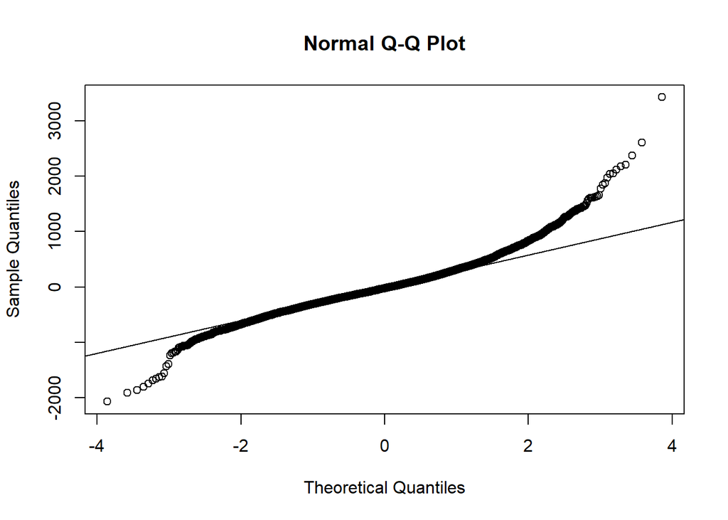

```r
# PLOT 1
qqnorm(resid(m2))
qqline(resid(m2))
```

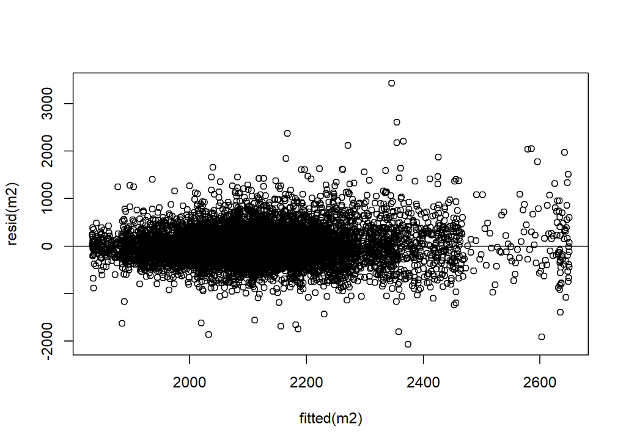

```r
# PLOT 2:
plot(fitted(m2), resid(m2))
abline(h=0)
```

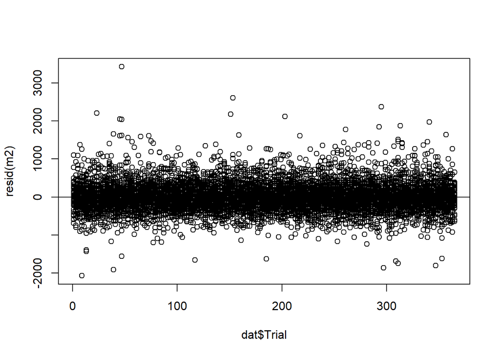

```r
plot(dat$Trial, resid(m2))
abline(h=0)
```

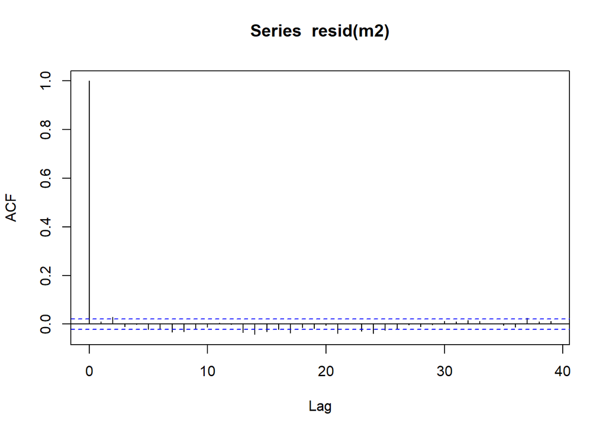

```r
# PLOT 3:
acf(resid(m2))
```

```
## Summary:
##  * Condition : factor; set to the value(s): DR, FF, RD.
##  * Trial : numeric predictor; with 30 values ranging from 1.000000 to 365.000000.
##  * Subject : factor; set to the value(s): s81112112644. (Might be canceled as random effect, check below.)
##  * NOTE : The following random effects columns are canceled: s(Trial,Subject)
##
```

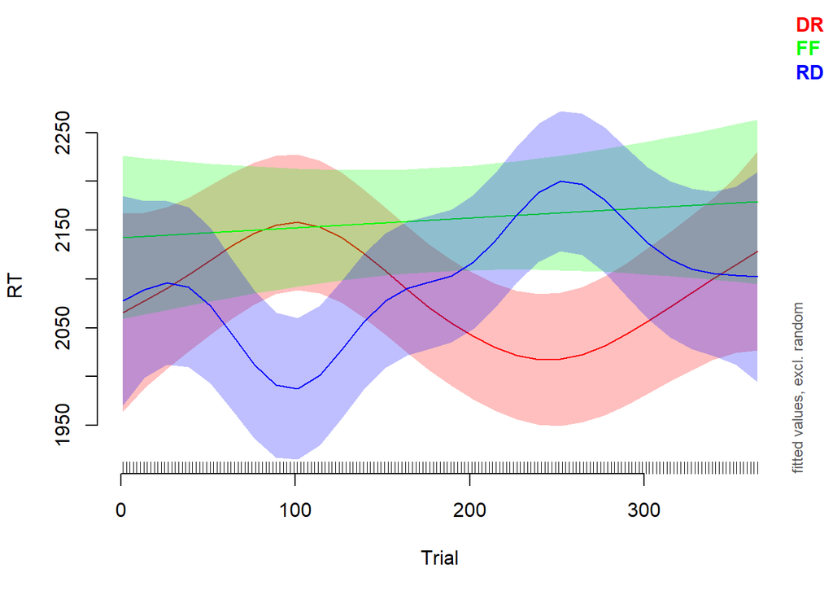

```r
#smooth plot showing the RTs by condition
plot_smooth(m2, view="Trial", plot_all="Condition")
```

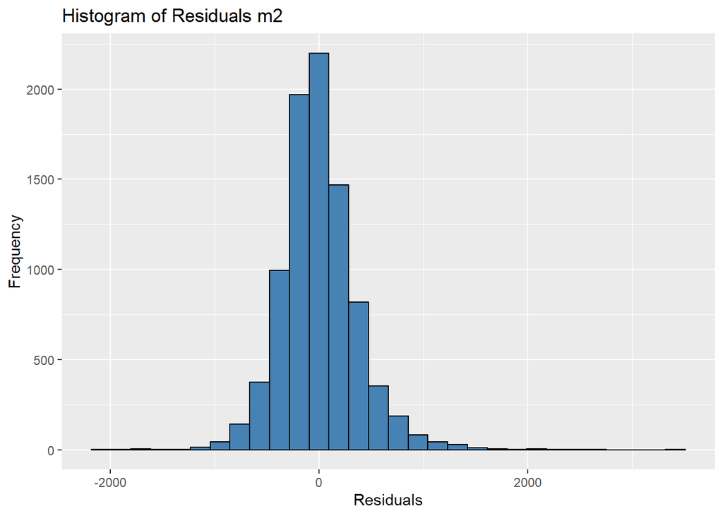

```r
#create histogram of residuals m2
ggplot(data = dat, aes(x = m2$residuals)) +
    geom_histogram(fill = 'steelblue', color = 'black') +
    labs(title = 'Histogram of Residuals m2', x = 'Residuals', y = 'Frequency')
```

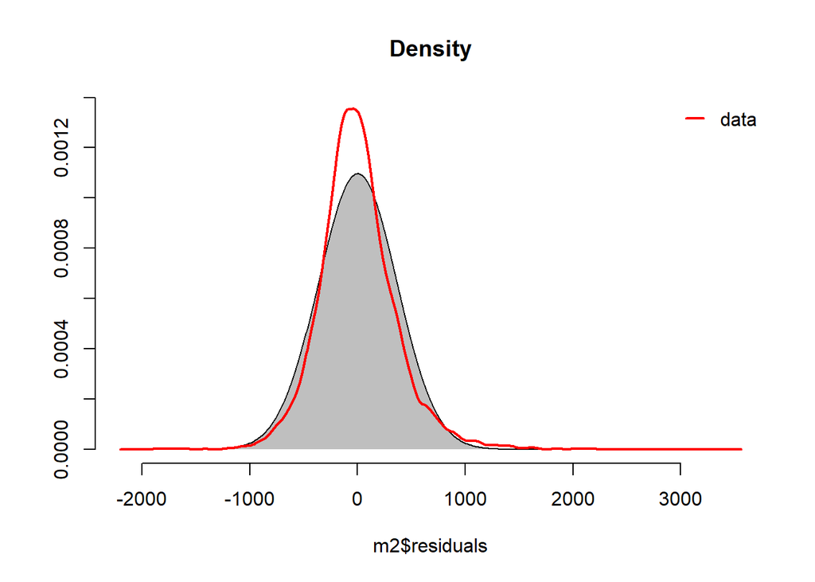

```r
#check normal distribution graph for residuals of m2
check_normaldist(m2$residuals, xlab = 'reaction time (ms)', title = 'residuals distribution m2')
```

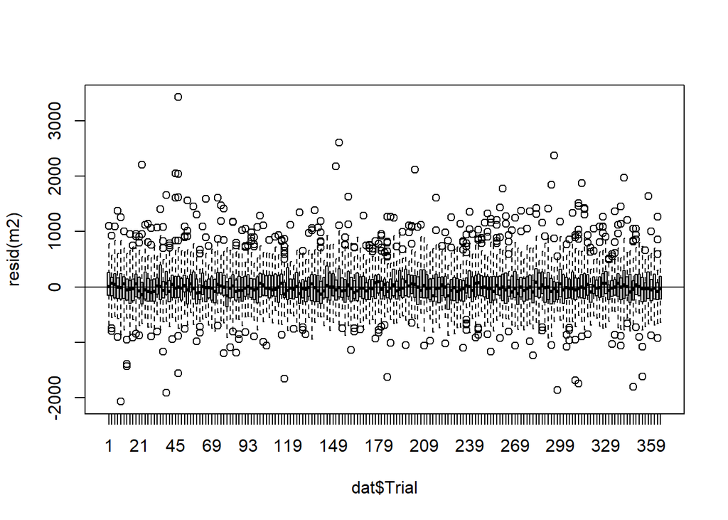

```r
#boxplot
boxplot(resid(m2) ~ dat$Trial)
abline(h=0)
```

qqnorm plot shows that the residuals do not follow a normal distribution (like the data and model m1). The residuals on the left end of the distribution are lower and the values on the right tail are higher. Overall, the residuals have a skewed distribution (on both ends).

resid vs fitted for m2 shows a wider range of fitted values in comparison to ml. The residuals show a slight alternating pattern in concentration of residuals like seen in m1 (although since the scales vary, they cannot be compared). However, the residuals show a slight trend of normal distribution. It is also evident from the plot that there are far more residuals towards the right end which suggests that the residuals follow a right-skewed distribution.

resid vs trial plot is similar to m1. There is not much difference in the concentration or magnitude of the residuals.

ACF lag 1 does not show correlation anymore. There is however a slight trend of alternating high and low ACF values as seen with model m1. However, this trend is much less evident.

Finally, the smooth plot shows the summed effect of the non-linear interaction between Trails and Condition on the RTs. The difference between the smooth plot of m1 and m2 is in the confidence interval which is much wider throughout all the trials instead of just the first and last few trials as seen in model m1.

**Based on your conclusions of Question 3b, do you think that further data cleaning and/or transformation is required?**

I think a log transformation of the RT and inverse transformation can be tried because the residuals are still skewed.

```r
#log transform RT
dat$logRT <- log(dat$RT)

m2l <- bam( logRT ~ Condition +  s(Trial, by = Condition) + s(Trial, Subject, bs='fs', m=1), data=dat)
summary(m2l)
```

```
##
## Family: gaussian
## Link function: identity
##
## Formula:
## logRT ~ Condition + s(Trial, by = Condition) + s(Trial, Subject,
##     bs = "fs", m = 1)
##
## Parametric coefficients:
##             Estimate Std. Error t value Pr(>|t|)
## (Intercept) 7.625789   0.011676 653.104   <2e-16 ***
## ConditionFF 0.031977   0.016518   1.936   0.0529 .
## ConditionRD 0.009708   0.016513   0.588   0.5566
## ---
## Signif. codes:  0 '***' 0.001 '**' 0.01 '*' 0.05 '.' 0.1 ' ' 1
##
## Approximate significance of smooth terms:
##                          edf  Ref.df     F  p-value
## s(Trial):ConditionDR   4.829   5.761 4.291 0.000373 ***
## s(Trial):ConditionFF   1.000   1.000 0.423 0.515398
## s(Trial):ConditionRD   6.432   7.470 4.573 9.15e-05 ***
## s(Trial,Subject)     164.128 429.000 2.134  < 2e-16 ***
## ---
## Signif. codes:  0 '***' 0.001 '**' 0.01 '*' 0.05 '.' 0.1 ' ' 1
##
## R-sq.(adj) =  0.112   Deviance explained =   13%
## fREML = -2578.4  Scale est. = 0.031087  n = 8761
```

```r
#inv transform
dat$invRT <- -1000/dat$RT

m2i <- bam( invRT ~ Condition +  s(Trial, by = Condition) + s(Trial, Subject, bs='fs', m=1), data=dat)
summary(m2i)
```

```
##
## Family: gaussian
## Link function: identity
##
## Formula:
## invRT ~ Condition + s(Trial, by = Condition) + s(Trial, Subject,
##     bs = "fs", m = 1)
##
## Parametric coefficients:
##              Estimate Std. Error t value Pr(>|t|)
## (Intercept) -0.497735   0.005436 -91.560   <2e-16 ***
## ConditionFF  0.014084   0.007692   1.831   0.0671 .
## ConditionRD  0.008347   0.007688   1.086   0.2776
## ---
## Signif. codes:  0 '***' 0.001 '**' 0.01 '*' 0.05 '.' 0.1 ' ' 1
##
## Approximate significance of smooth terms:
##                          edf  Ref.df     F p-value
## s(Trial):ConditionDR   4.275   5.186 3.177 0.00688 **
## s(Trial):ConditionFF   1.757   2.082 0.820 0.42097
## s(Trial):ConditionRD   4.186   5.081 2.925 0.01177 *
## s(Trial,Subject)     118.415 429.000 0.943 < 2e-16 ***
## ---
## Signif. codes:  0 '***' 0.001 '**' 0.01 '*' 0.05 '.' 0.1 ' ' 1
##
## R-sq.(adj) =  0.0525   Deviance explained = 6.66%
## fREML = -6016.7  Scale est. = 0.014378  n = 8761
```

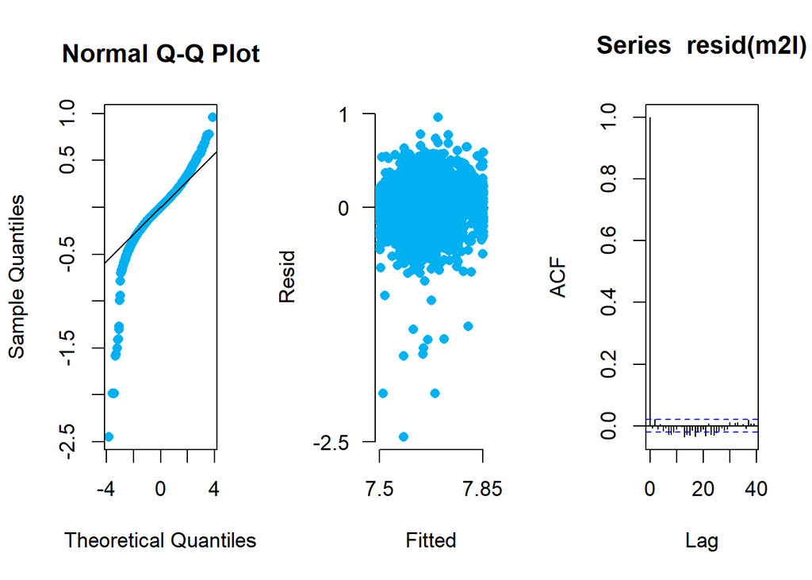

```r
#visualization
par(mfrow=c(1,3), cex=1.1)
# PLOT 1
qqnorm(resid(m2l), pch=16, col=alpha("#00B0F0"))
qqline(resid(m2l))

# PLOT 2
emptyPlot(range(fitted(m2l)), range(resid(m2l)),
    h0=0,
    xlab="Fitted", ylab="Resid",
    xmark=TRUE, ymark=TRUE, las=1)
points(fitted(m2l), resid(m2l), pch=16, col=alpha("#00B0F0"))

# PLOT 3
acf(resid(m2l))
```

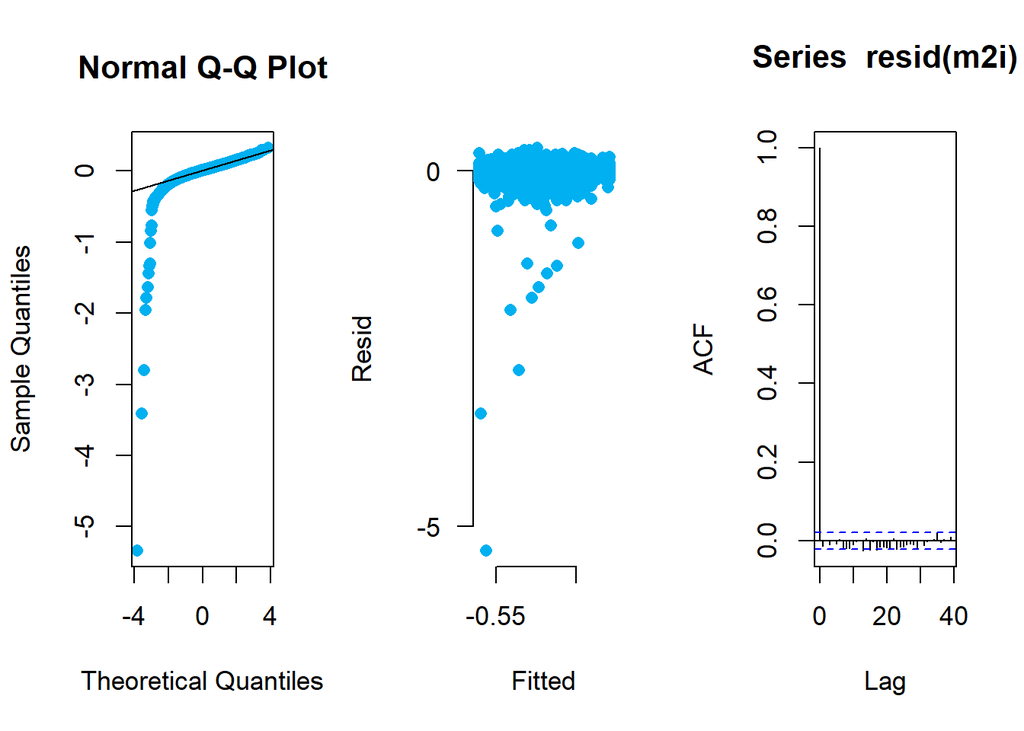

```r
par(mfrow=c(1,3), cex=1.1)
# PLOT 1
qqnorm(resid(m2i), pch=16, col=alpha("#00B0F0"))
qqline(resid(m2i))

# PLOT 2
emptyPlot(range(fitted(m2i)), range(resid(m2i)),
    h0=0,
    xlab="Fitted", ylab="Resid",
    xmark=TRUE, ymark=TRUE, las=1)
points(fitted(m2i), resid(m2i), pch=16, col=alpha("#00B0F0"))

# PLOT 3
acf(resid(m2i))
```

It is difficult to interpret and compare these plots since they are on different scales. Thus a model comparison can be done.

```r
m2 <- bam( RT ~ Condition +  s(Trial, by = Condition) + s(Trial, Subject, bs='fs', m=1), data=dat,
           method ='ML')
summary(m2)
```

```
##
## Family: gaussian
## Link function: identity
##
## Formula:
## RT ~ Condition + s(Trial, by = Condition) + s(Trial, Subject,
##     bs = "fs", m = 1)
##
## Parametric coefficients:
##             Estimate Std. Error t value Pr(>|t|)
## (Intercept)  2085.64      26.25  79.453   <2e-16 ***
## ConditionFF    75.12      37.13   2.023   0.0431 *
## ConditionRD    12.59      37.12   0.339   0.7344
## ---
## Signif. codes:  0 '***' 0.001 '**' 0.01 '*' 0.05 '.' 0.1 ' ' 1
##
## Approximate significance of smooth terms:
##                          edf  Ref.df     F  p-value
## s(Trial):ConditionDR   4.435   5.280 3.960 0.001133 **
## s(Trial):ConditionFF   1.034   1.049 0.313 0.595865
## s(Trial):ConditionRD   6.392   7.415 4.528 0.000115 ***
## s(Trial,Subject)     174.961 429.000 2.638  < 2e-16 ***
## ---
## Signif. codes:  0 '***' 0.001 '**' 0.01 '*' 0.05 '.' 0.1 ' ' 1
##
## R-sq.(adj) =  0.133   Deviance explained = 15.2%
## -ML =  64377  Scale est. = 1.352e+05  n = 8761
```

```r
m2l <- bam( logRT ~ Condition +  s(Trial, by = Condition) + s(Trial, Subject, bs='fs', m=1), data=dat,
            method='ML')
summary(m2l)
```

```
##
## Family: gaussian
## Link function: identity
##
## Formula:
## logRT ~ Condition + s(Trial, by = Condition) + s(Trial, Subject,
##     bs = "fs", m = 1)
##
## Parametric coefficients:
##             Estimate Std. Error t value Pr(>|t|)
## (Intercept) 7.625789   0.011306 674.470   <2e-16 ***
## ConditionFF 0.031979   0.015995   1.999   0.0456 *
## ConditionRD 0.009708   0.015990   0.607   0.5438
## ---
## Signif. codes:  0 '***' 0.001 '**' 0.01 '*' 0.05 '.' 0.1 ' ' 1
##
## Approximate significance of smooth terms:
##                          edf  Ref.df     F  p-value
## s(Trial):ConditionDR   4.618   5.517 4.381 0.000388 ***
## s(Trial):ConditionFF   1.002   1.003 0.432 0.512233
## s(Trial):ConditionRD   6.074   7.119 4.434 0.000101 ***
## s(Trial,Subject)     163.104 429.000 2.123  < 2e-16 ***
## ---
## Signif. codes:  0 '***' 0.001 '**' 0.01 '*' 0.05 '.' 0.1 ' ' 1
##
## R-sq.(adj) =  0.111   Deviance explained = 12.9%
## -ML = -2597.4  Scale est. = 0.031096  n = 8761
```

```r
m2i <- bam( invRT ~ Condition +  s(Trial, by = Condition) + s(Trial, Subject, bs='fs', m=1), data=dat,
            method='ML')
summary(m2i)
```

```
##
## Family: gaussian
## Link function: identity
##
## Formula:
## invRT ~ Condition + s(Trial, by = Condition) + s(Trial, Subject,
##     bs = "fs", m = 1)
##
## Parametric coefficients:
##              Estimate Std. Error t value Pr(>|t|)
## (Intercept) -0.497734   0.005263 -94.569   <2e-16 ***
## ConditionFF  0.014105   0.007448   1.894   0.0583 .
## ConditionRD  0.008345   0.007443   1.121   0.2622
## ---
## Signif. codes:  0 '***' 0.001 '**' 0.01 '*' 0.05 '.' 0.1 ' ' 1
##
## Approximate significance of smooth terms:
##                          edf  Ref.df     F p-value
## s(Trial):ConditionDR   4.004   4.864 3.210 0.00771 **
## s(Trial):ConditionFF   1.014   1.022 0.472 0.50612
## s(Trial):ConditionRD   3.859   4.689 2.999 0.01268 *
## s(Trial,Subject)     118.017 429.000 0.938 < 2e-16 ***
## ---
## Signif. codes:  0 '***' 0.001 '**' 0.01 '*' 0.05 '.' 0.1 ' ' 1
##
## R-sq.(adj) =  0.0522   Deviance explained = 6.62%
## -ML =  -6040  Scale est. = 0.014382  n = 8761
```

```r
#model comparison
compareML(m2, m2l)
```

```
## m2: RT ~ Condition + s(Trial, by = Condition) + s(Trial, Subject,
##     bs = "fs", m = 1)
##
## m2l: logRT ~ Condition + s(Trial, by = Condition) + s(Trial, Subject,
##     bs = "fs", m = 1)
##
## Model m2l preferred: lower ML score (66974.661), and equal df (0.000).
## -----
##   Model     Score Edf Difference    Df
## 1    m2 64377.255  11
## 2   m2l -2597.405  11 -66974.661 0.000
##
## AIC difference: 133925.47, model m2l has lower AIC.
```

```r
compareML(m2, m2i)
```

```
## m2: RT ~ Condition + s(Trial, by = Condition) + s(Trial, Subject,
##     bs = "fs", m = 1)
##
## m2i: invRT ~ Condition + s(Trial, by = Condition) + s(Trial, Subject,
##     bs = "fs", m = 1)
##
## Model m2i preferred: lower ML score (70417.239), and equal df (0.000).
## -----
##   Model     Score Edf Difference    Df
## 1    m2 64377.255  11
## 2   m2i -6039.984  11 -70417.239 0.000
##
## AIC difference: 140729.11, model m2i has lower AIC.
```

## Question 4: Interpretation and significance testing

**Print the summary of model m2 (the final result of Question 3). Explain what you can conclude from the summary about the effects of Condition and Trial.**

```r
summary(m2)
```

```
##
## Family: gaussian
## Link function: identity
##
## Formula:
## RT ~ Condition + s(Trial, by = Condition) + s(Trial, Subject,
##     bs = "fs", m = 1)
##
## Parametric coefficients:
##             Estimate Std. Error t value Pr(>|t|)
## (Intercept)  2085.64      26.25  79.453   <2e-16 ***
## ConditionFF    75.12      37.13   2.023   0.0431 *
## ConditionRD    12.59      37.12   0.339   0.7344
## ---
## Signif. codes:  0 '***' 0.001 '**' 0.01 '*' 0.05 '.' 0.1 ' ' 1
##
## Approximate significance of smooth terms:
##                          edf  Ref.df     F  p-value
## s(Trial):ConditionDR   4.435   5.280 3.960 0.001133 **
## s(Trial):ConditionFF   1.034   1.049 0.313 0.595865
## s(Trial):ConditionRD   6.392   7.415 4.528 0.000115 ***
## s(Trial,Subject)     174.961 429.000 2.638  < 2e-16 ***
## ---
## Signif. codes:  0 '***' 0.001 '**' 0.01 '*' 0.05 '.' 0.1 ' ' 1
##
## R-sq.(adj) =  0.133   Deviance explained = 15.2%
## -ML =  64377  Scale est. = 1.352e+05  n = 8761
```

Based on the summary, the estimated non-linear interaction between Trial:ConditionDR and Trial:ConditionRD, are significant. However, we cannot tell whether there is a difference in RTs for the three conditions over time. Finally, the factor smooth term s(Trial,Subject) is evidently significant suggesting that over the trials, the RTs of subjects differ significantly, thus this term accounts for the variance in the data. Lastly, the deviance explained is extremely low and which may suggest that the fixed effects and non-linear interactions in model m2 do not account for all variance in the data. prev.Duration may be a good fixed effect addition to the model.

**Visualize the effects of Condition and Trial using the function plot_smooth and the differences between conditions using the function plot_diff. Include the following in your R Markdown report:**

```r
par(mfrow=c(2,2), cex=0.7)

plot_smooth(m2, view="Trial", plot_all="Condition",
      main="Summed effects",
      xmark=range(dat$Trial), ymark=TRUE, las=1)
```

```
## Summary:
##  * Condition : factor; set to the value(s): DR, FF, RD.
##  * Trial : numeric predictor; with 30 values ranging from 1.000000 to 365.000000.
##  * Subject : factor; set to the value(s): s81112112644. (Might be canceled as random effect, check below.)
##  * NOTE : The following random effects columns are canceled: s(Trial,Subject)
##
```

```r
plot_diff(m2, view="Trial", comp=list(Condition=c('RD','DR')),
      xmark=range(dat$Trial), ymark=TRUE, las=1)
```

```
## Summary:
##  * Trial : numeric predictor; with 100 values ranging from 1.000000 to 365.000000.
##  * Subject : factor; set to the value(s): s81112112644. (Might be canceled as random effect, check below.)
##  * NOTE : The following random effects columns are canceled: s(Trial,Subject)
##
```

```
##
## Trial window(s) of significant difference(s):
##  70.858586 - 129.686869
##  210.575758 - 291.464646
```

```r
plot_diff(m2, view="Trial", comp=list(Condition=c('RD','FF')),
      xmark=range(dat$Trial), ymark=TRUE, las=1)
```

```
## Summary:
##  * Trial : numeric predictor; with 100 values ranging from 1.000000 to 365.000000.
##  * Subject : factor; set to the value(s): s81112112644. (Might be canceled as random effect, check below.)
##  * NOTE : The following random effects columns are canceled: s(Trial,Subject)
##
```

```
##
## Trial window(s) of significant difference(s):
##  63.505051 - 148.070707
```

```
## Summary:
##  * Trial : numeric predictor; with 100 values ranging from 1.000000 to 365.000000.
##  * Subject : factor; set to the value(s): s81112112644. (Might be canceled as random effect, check below.)
##  * NOTE : The following random effects columns are canceled: s(Trial,Subject)
##
```

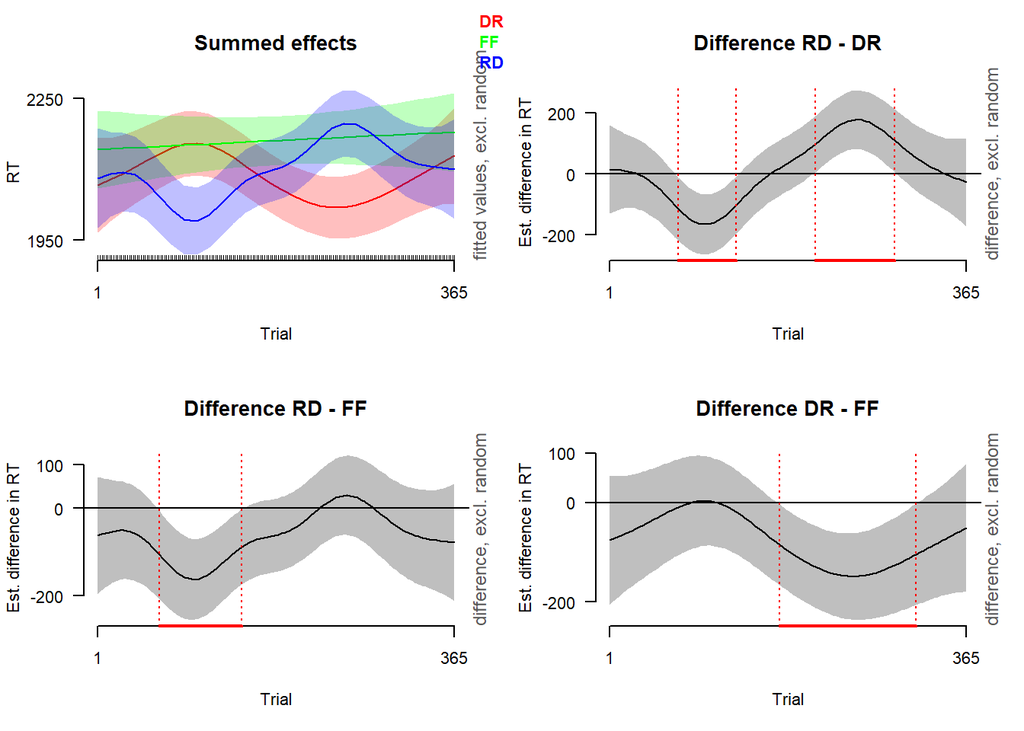

```
##
## Trial window(s) of significant difference(s):
##  173.808081 - 313.525253
```

```r
plot_diff(m2, view="Trial", comp=list(Condition=c('DR','FF')),
      xmark=range(dat$Trial), ymark=TRUE, las=1)
```

The summed effects plot shows alternate peaks and trough of conditionRD and conditionDR respectively which suggests that over trials the RTs differs for these conditions. However, for conditionFF the RTs do not differ as significantly with trials. This can be seen from the almost straight line of the RTs for conditionFF throughout the trials. But it can be seen that the pattern for RTs is different for each condition. It is unclear whether this difference is over the trials or due to difference in intercept of the conditions.

The difference plots for conditionRD and conditionDR show significant difference in RTs between trials 70 - 129 and trials 210 - 291 approximately.

It is unclear whether non-linear interaction between conditions and trials is different due to the difference in their average RTs in each condition or whether there is trend difference over the trials. However, since each condition shows a different pattern, this non-linear interaction seems significant.

**Run a model-comparison procedure with the function compareML to determine the best-fitting model. Include the following in your R Markdown report**

```r
#model with non-linear interaction between trial and condition as fixed effect
m1 <- bam( RT ~ Condition + s(Trial, by = Condition), method="ML", data=dat)
summary(m1)
```

```
##
## Family: gaussian
## Link function: identity
##
## Formula:
## RT ~ Condition + s(Trial, by = Condition)
##
## Parametric coefficients:
##             Estimate Std. Error t value Pr(>|t|)
## (Intercept) 2085.639      7.223 288.753  < 2e-16 ***
## ConditionFF   75.877     10.235   7.413 1.35e-13 ***
## ConditionRD   12.595     10.215   1.233    0.218
## ---
## Signif. codes:  0 '***' 0.001 '**' 0.01 '*' 0.05 '.' 0.1 ' ' 1
##
## Approximate significance of smooth terms:
##                        edf Ref.df     F p-value
## s(Trial):ConditionDR 4.737  5.799 8.281  <2e-16 ***
## s(Trial):ConditionFF 1.002  1.004 5.399  0.0201 *
## s(Trial):ConditionRD 6.480  7.622 9.027  <2e-16 ***
## ---
## Signif. codes:  0 '***' 0.001 '**' 0.01 '*' 0.05 '.' 0.1 ' ' 1
##
## R-sq.(adj) =  0.0206   Deviance explained = 2.22%
## -ML =  64735  Scale est. = 1.5275e+05  n = 8761
```

```r
#model without non-linear interaction between trial and condition
c2 <- bam( RT ~ Condition, method="ML", data=dat)
summary(c2)
```

```
##
## Family: gaussian
## Link function: identity
##
## Formula:
## RT ~ Condition
##
## Parametric coefficients:
##             Estimate Std. Error t value Pr(>|t|)
## (Intercept) 2085.687      7.274 286.747  < 2e-16 ***
## ConditionFF   75.693     10.307   7.344 2.26e-13 ***
## ConditionRD   12.566     10.286   1.222    0.222
## ---
## Signif. codes:  0 '***' 0.001 '**' 0.01 '*' 0.05 '.' 0.1 ' ' 1
##
##
## R-sq.(adj) =  0.00679   Deviance explained = 0.702%
## -ML =  64779  Scale est. = 1.5491e+05  n = 8761
```

```r
compareML(m1, c2)
```

```
## m1: RT ~ Condition + s(Trial, by = Condition)
##
## c2: RT ~ Condition
```

```
##
## Chi-square test of ML scores
## -----
##   Model    Score Edf Difference    Df  p.value Sig.
## 1    c2 64779.33   3
## 2    m1 64734.71   9     44.620 6.000  < 2e-16  ***
##
## AIC difference: -106.45, model m1 has lower AIC.
```

Model comparison is done to check the significance of the non-linear interaction between trial and condition. The model comparison test shows a significant difference between the models, X2 (6) = 44.620, p < 2.2e-16. It can be seen that by spending 6 additional degree of freedom, the deviance drops by 44.620. This means that our model m1 with non-linear interaction fits the data better. Now, I shall manually model Condition using dummy predictors for DR and RD to compare it with the FF condition and check whether the conditions differ from each other over trials (here, I’m checking if they differ from FF).

```r
#check contrast
contrasts(dat$Condition)
```

```
##    FF RD
## DR  0  0
## FF  1  0
## RD  0  1
```

```r
#dummy predictors for RD and DR conditions:
dat$RD <- ifelse(dat$Condition=='RD', 1, 0)
dat$DR <- ifelse(dat$Condition=='DR', 1, 0)
#dat$FF <- ifelse(dat$Condition=='FF', 1, 0)

model1 <- bam( RT ~  s(Trial) + s(Trial, by = DR) + s(Trial, by = RD), data=dat)
summary(model1)
```

```
##
## Family: gaussian
## Link function: identity
##
## Formula:
## RT ~ s(Trial) + s(Trial, by = DR) + s(Trial, by = RD)
##
## Parametric coefficients:
##             Estimate Std. Error t value Pr(>|t|)
## (Intercept) 2161.516      7.251   298.1   <2e-16 ***
## ---
## Signif. codes:  0 '***' 0.001 '**' 0.01 '*' 0.05 '.' 0.1 ' ' 1
##
## Approximate significance of smooth terms:
##               edf Ref.df      F p-value
## s(Trial)    1.001  1.001  5.412    0.02 *
## s(Trial):DR 5.919  7.004 15.499  <2e-16 ***
## s(Trial):RD 7.740  8.855 10.066  <2e-16 ***
## ---
## Signif. codes:  0 '***' 0.001 '**' 0.01 '*' 0.05 '.' 0.1 ' ' 1
##
## R-sq.(adj) =  0.0207   Deviance explained = 2.24%
## fREML =  64712  Scale est. = 1.5273e+05  n = 8761
```

In the above model, the non-linear smooths show the difference in RTs over trial in comparison to the reference level (conditionFF). This suggests that the conditions follow a different trend over trials. Thus model m1 with the non-linear interaction should be used with random effects to account for subject variability.

```r
m2 <- bam( RT ~ Condition +  s(Trial, by = Condition) + s(Trial, Subject, bs='fs', m=1), data=dat)
summary(m2)
```

```
##
## Family: gaussian
## Link function: identity
##
## Formula:
## RT ~ Condition + s(Trial, by = Condition) + s(Trial, Subject,
##     bs = "fs", m = 1)
##
## Parametric coefficients:
##             Estimate Std. Error t value Pr(>|t|)
## (Intercept)  2085.64      27.11  76.936   <2e-16 ***
## ConditionFF    75.12      38.35   1.959   0.0502 .
## ConditionRD    12.60      38.34   0.329   0.7425
## ---
## Signif. codes:  0 '***' 0.001 '**' 0.01 '*' 0.05 '.' 0.1 ' ' 1
##
## Approximate significance of smooth terms:
##                          edf  Ref.df     F  p-value
## s(Trial):ConditionDR   4.639   5.518 3.895  0.00116 **
## s(Trial):ConditionFF   1.001   1.001 0.307  0.58018
## s(Trial):ConditionRD   6.649   7.656 4.576 8.88e-05 ***
## s(Trial,Subject)     175.917 429.000 2.650  < 2e-16 ***
## ---
## Signif. codes:  0 '***' 0.001 '**' 0.01 '*' 0.05 '.' 0.1 ' ' 1
##
## R-sq.(adj) =  0.133   Deviance explained = 15.2%
## fREML =  64350  Scale est. = 1.3517e+05  n = 8761
```

## Question 5: Alternative analyses 1

**Setup a GAMM model that includes the nonlinear effect of prev.Dur, and include random effects. Include the following in your R Markdown report:the code for the model; a short explanation of why you included these model terms, and why you decided to leave out other terms (if any); a short summary of the effect of prev.Dur, illustrated with an appropriate plot.**

```r
#check for NA value
sum(is.na(dat$prev.Dur[dat$Condition == 'RD']))
```

```
## [1] 16
```

```r
sum(is.na(dat$prev.Dur[dat$Condition == 'DR']))
```

```
## [1] 16
```

```r
sum(is.na(dat$prev.Dur[dat$Condition == 'FF']))
```

```
## [1] 16
```

```r
#removing the NA values
dat <- na.omit(dat)
range(dat$prev.Dur)
```

```
## [1] 2600 3600
```

```r
mean(dat$prev.Dur)
```

```
## [1] 3101.131
```

```r
m3  <- bam( RT ~ s(prev.Dur, by = Condition) + s(Trial, Subject, bs='fs', m=1), data=dat)
summary(m3)
```

```
##
## Family: gaussian
## Link function: identity
##
## Formula:
## RT ~ s(prev.Dur, by = Condition) + s(Trial, Subject, bs = "fs",
##     m = 1)
##
## Parametric coefficients:
##             Estimate Std. Error t value Pr(>|t|)
## (Intercept)     2092         19   110.1   <2e-16 ***
## ---
## Signif. codes:  0 '***' 0.001 '**' 0.01 '*' 0.05 '.' 0.1 ' ' 1
##
## Approximate significance of smooth terms:
##                             edf  Ref.df      F  p-value
## s(prev.Dur):ConditionDR   1.620   1.885 12.047 1.06e-05 ***
## s(prev.Dur):ConditionFF   1.000   1.000  4.246   0.0394 *
## s(prev.Dur):ConditionRD   2.926   3.543 12.823  < 2e-16 ***
## s(Trial,Subject)        177.629 430.000  2.633  < 2e-16 ***
## ---
## Signif. codes:  0 '***' 0.001 '**' 0.01 '*' 0.05 '.' 0.1 ' ' 1
##
## R-sq.(adj) =  0.134   Deviance explained = 15.2%
## fREML =  63990  Scale est. = 1.3518e+05  n = 8713
```

```r
#with binary coding
m4  <- bam( RT ~ s(prev.Dur, by = RD) + s(prev.Dur, by = DR) + s(Trial, Subject, bs='fs', m=1), data=dat)
summary(m4)
```

```
##
## Family: gaussian
## Link function: identity
##
## Formula:
## RT ~ s(prev.Dur, by = RD) + s(prev.Dur, by = DR) + s(Trial, Subject,
##     bs = "fs", m = 1)
##
## Parametric coefficients:
##             Estimate Std. Error t value Pr(>|t|)
## (Intercept)  2159.96      27.04   79.89   <2e-16 ***
## ---
## Signif. codes:  0 '***' 0.001 '**' 0.01 '*' 0.05 '.' 0.1 ' ' 1
##
## Approximate significance of smooth terms:
##                      edf  Ref.df      F  p-value
## s(prev.Dur):RD     3.944   4.566 10.550  < 2e-16 ***
## s(prev.Dur):DR     2.643   2.913  9.199 5.21e-06 ***
## s(Trial,Subject) 176.758 429.000  2.635  < 2e-16 ***
## ---
## Signif. codes:  0 '***' 0.001 '**' 0.01 '*' 0.05 '.' 0.1 ' ' 1
##
## R-sq.(adj) =  0.134   Deviance explained = 15.2%
## fREML =  63991  Scale est. = 1.3517e+05  n = 8713
```

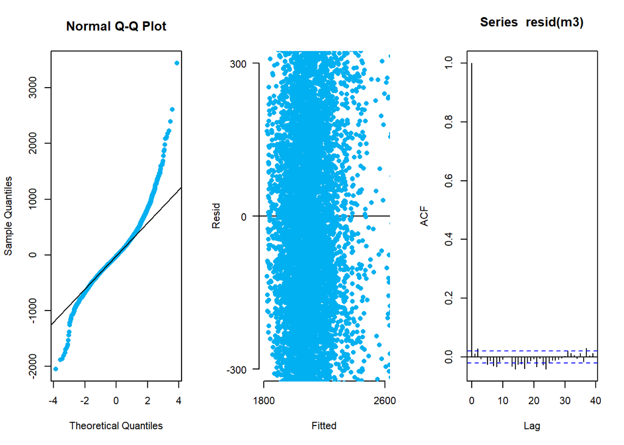

```r
#visualization for model m3
par(mfrow=c(1,3), cex=0.7)
# PLOT 1
qqnorm(resid(m3), pch=16, col=alpha("#00B0F0"))
qqline(resid(m3))

# PLOT 2
emptyPlot(c(1800, 2600), c(-300, 300),
    h0=0,
    xlab="Fitted", ylab="Resid",
    xmark=TRUE, ymark=TRUE, las=1)
points(fitted(m3), resid(m3), pch=16, col=alpha("#00B0F0"))

# PLOT 3
acf(resid(m3))
```

**a short explanation of why you included these model terms, and why you decided to leave out other terms (if any);**

A non-linear interaction between prev.dur and Condition is added to check if the RTs differ based on previous duration for different conditions. The non-linear interaction between consition and trial is left out because I specifically wanted to check just the influence of the prev.Duration on the RTs for each condition. Since the hypothesis is to test whether long intervals (varied across conditions) affect the short intervals. This model seemed appropriate.

**a short summary of the effect of prev.Dur, illustrated with an appropriate plot.**

```
## Summary:
##  * prev.Dur : numeric predictor; with 30 values ranging from 2600.000000 to 3600.000000.
##  * Condition : factor; set to the value(s): DR, FF, RD.
##  * Trial : numeric predictor; set to the value(s): 183. (Might be canceled as random effect, check below.)
##  * Subject : factor; set to the value(s): s81112112644. (Might be canceled as random effect, check below.)
##  * NOTE : The following random effects columns are canceled: s(Trial,Subject)
##
```

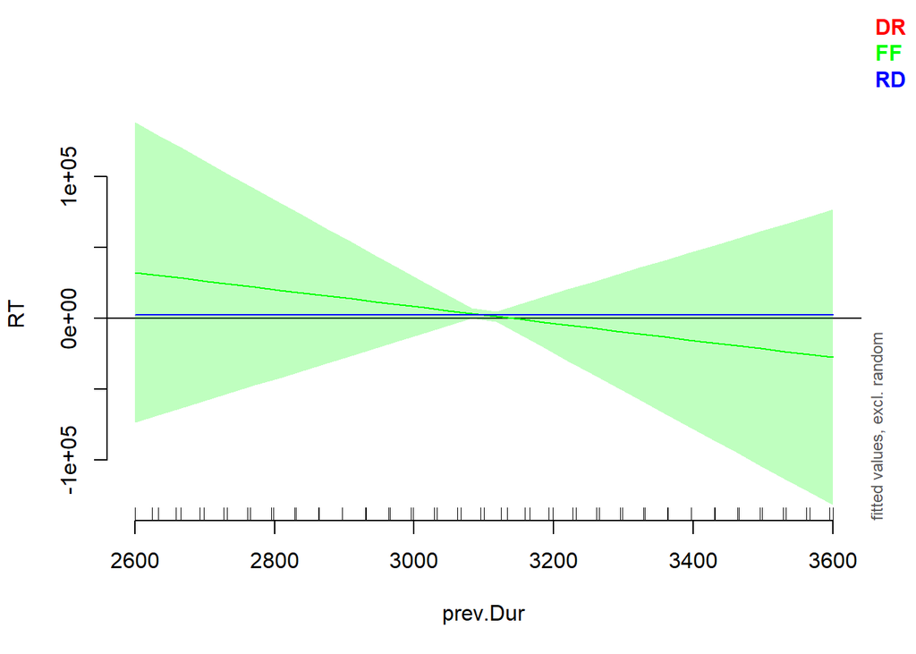

```r
#plot with prev.Dur
plot_smooth(m3, view="prev.Dur", plot_all="Condition")
```

## Alternative analysis 2:

We turn back to our original implementation, which included Trial and Condition, instead of prev.Dur. This time we would like to analyze the participant averages per block rather than including all trials.

**Construct a new data frame with per participant and per block the following information:the average reaction times (column RT); the number of measurements (i.e., the number of observations the average RT was based on); the condition (column Condition). Include the code and the first lines of the data frame in your report.**

```r
newdat <- ddply(dat, c("Subject", "Block", 'Condition'),
             summarise,
            RT = mean(RT),
            num = length(Trial))
head(newdat)
```

```
##        Subject Block Condition       RT num
## 1 s81112112644     1        DR 2125.964  22
## 2 s81112112644     2        DR 2098.921  17
## 3 s81112112644     3        DR 2125.300  23
## 4 s81112112644     4        DR 2023.288  17
## 5 s81112112644     5        DR 2002.463  23
## 6 s81112112644     6        DR 1901.233  17
```

**Setup a GAMM model (including random effects) to analyze the data, and run the model. Include the following in your report: the code for the model; a short summary of the estimated effects of the model (include plots).**

```r
p1 <- bam(RT ~ s(Block, by=Condition, k=4) + s(Subject, Block, bs='fs', m=1, k=4), data = newdat )
summary(p1)
```

```
##
## Family: gaussian
## Link function: identity
##
## Formula:
## RT ~ s(Block, by = Condition, k = 4) + s(Subject, Block, bs = "fs",
##     m = 1, k = 4)
##
## Parametric coefficients:
##             Estimate Std. Error t value Pr(>|t|)
## (Intercept)  2114.33      16.03   131.9   <2e-16 ***
## ---
## Signif. codes:  0 '***' 0.001 '**' 0.01 '*' 0.05 '.' 0.1 ' ' 1
##
## Approximate significance of smooth terms:
##                          edf  Ref.df     F p-value
## s(Block):ConditionDR   2.865   2.948 5.392 0.00094 ***
## s(Block):ConditionFF   1.000   1.000 0.921 0.33798
## s(Block):ConditionRD   2.845   2.939 5.328 0.00155 **
## s(Subject,Block)     111.480 191.000 3.781 < 2e-16 ***
## ---
## Signif. codes:  0 '***' 0.001 '**' 0.01 '*' 0.05 '.' 0.1 ' ' 1
##
## R-sq.(adj) =  0.649   Deviance explained = 74.6%
## fREML = 2690.7  Scale est. = 9502.2    n = 431
```

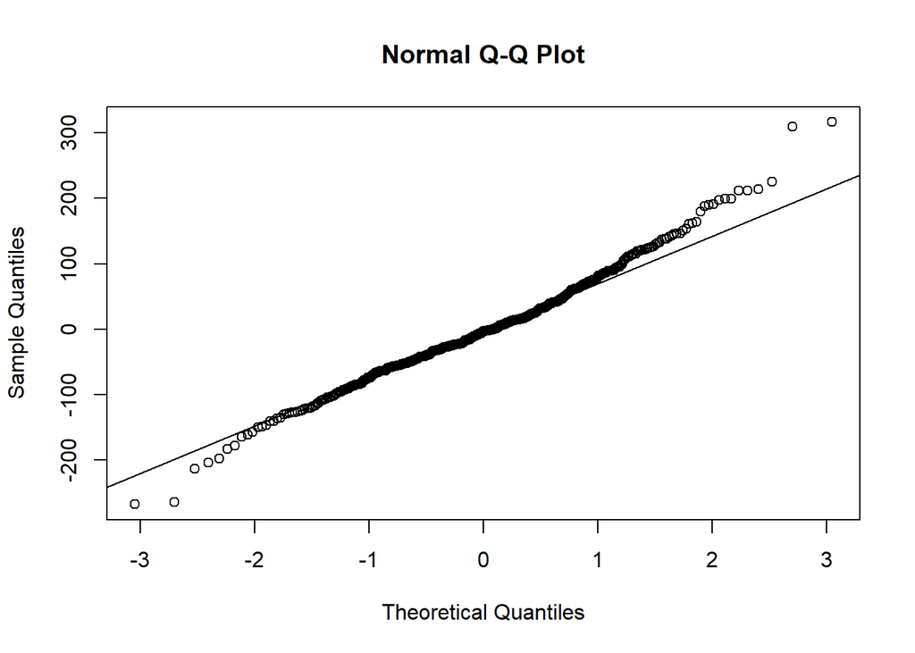

```r
# PLOT 1
qqnorm(resid(p1))
qqline(resid(p1))
```

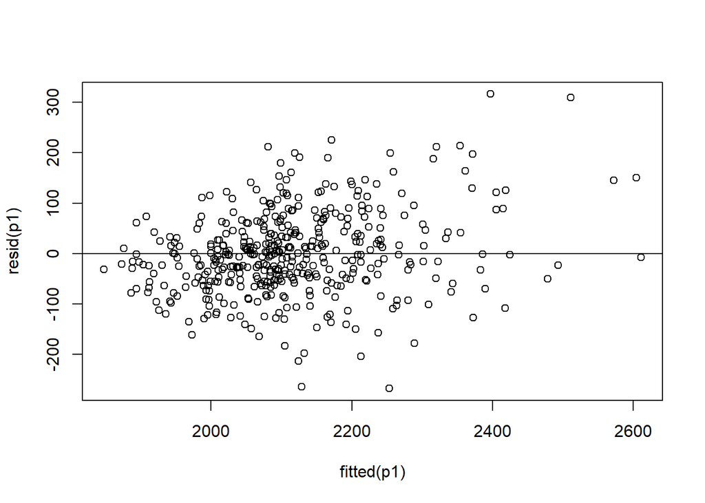

```r
# PLOT 2:
plot(fitted(p1), resid(p1))
abline(h=0)
```

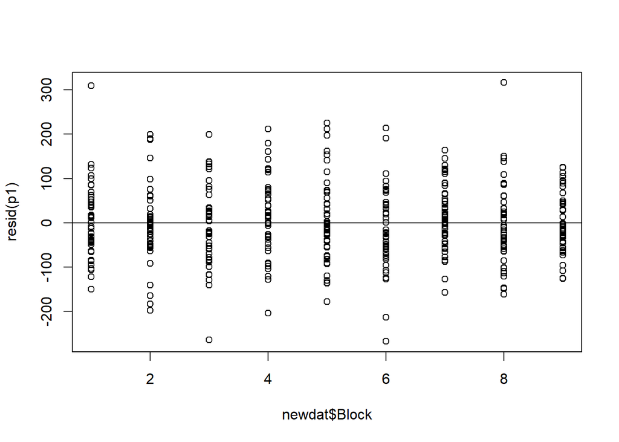

```r
plot(newdat$Block, resid(p1))
abline(h=0)
```

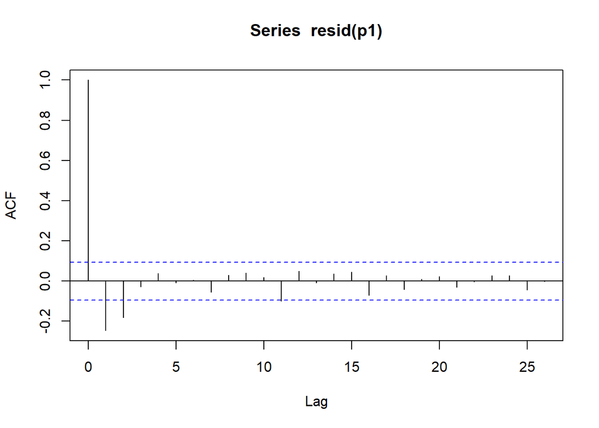

```r
# PLOT 3:
acf(resid(p1))
```

```
## Summary:
##  * Block : numeric predictor; with 30 values ranging from 1.000000 to 9.000000.
##  * Condition : factor; set to the value(s): DR, FF, RD.
##  * Subject : factor; set to the value(s): s81112112644. (Might be canceled as random effect, check below.)
##  * NOTE : The following random effects columns are canceled: s(Subject,Block)
##
```

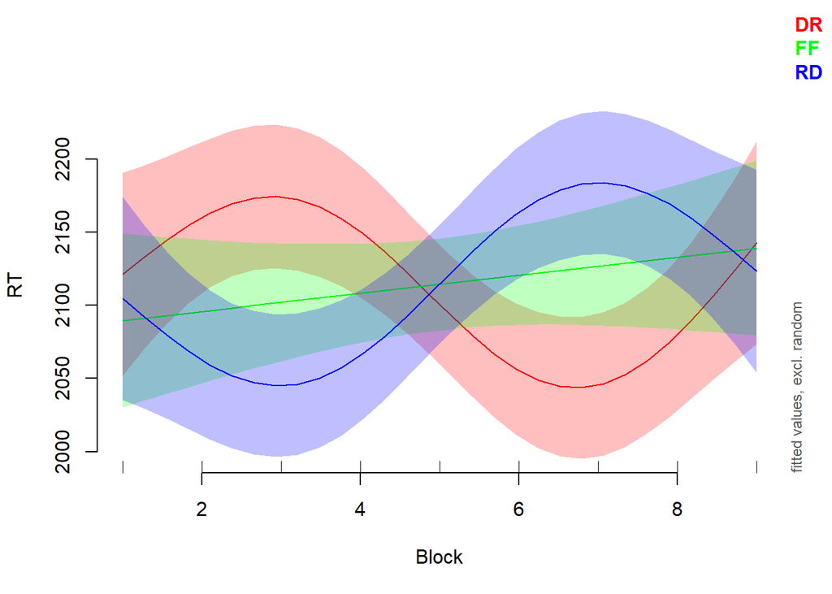

```r
#smooth plot showing the RTs by condition
plot_smooth(p1, view="Block", plot_all="Condition")
```

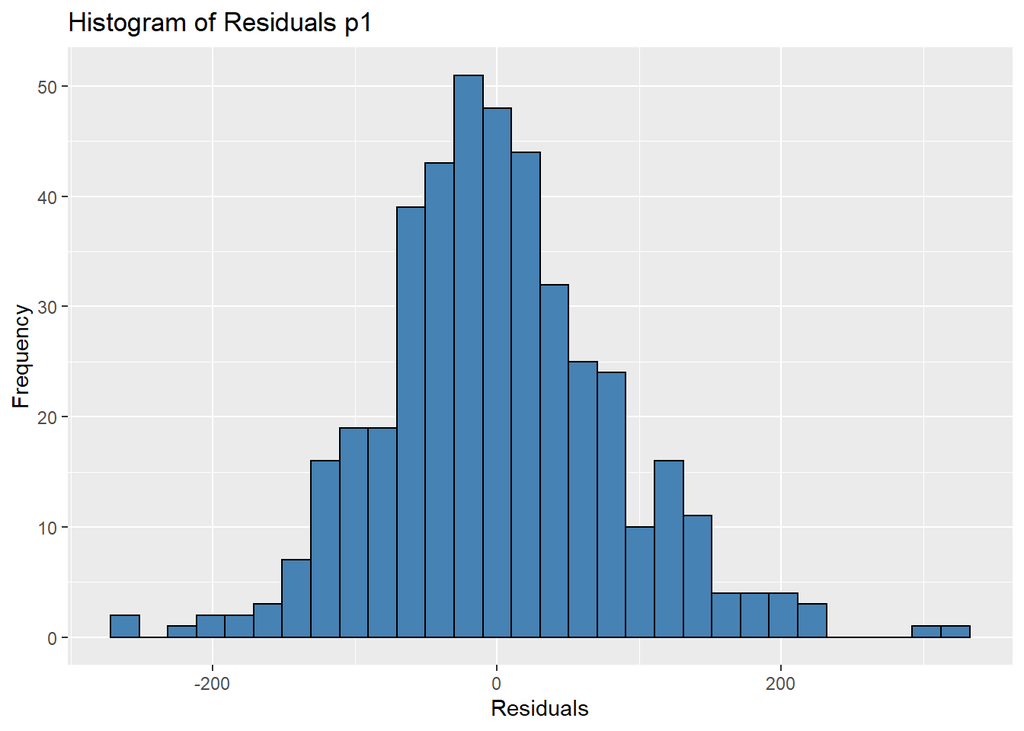

```r
#create histogram of residuals m2
ggplot(data = newdat, aes(x = p1$residuals)) +
    geom_histogram(fill = 'steelblue', color = 'black') +
    labs(title = 'Histogram of Residuals p1', x = 'Residuals', y = 'Frequency')
```